# a3_task3_shayan_kaveh

Shayan Kaveh

10/23/2021

## Overview

This code explores data on red and purple sea urchins recorded by Santa Barbara Coastal Long Term Ecological Research program divers. It looks at the distribution of red and purple urchins at 5 sites from 2008 to 2020, which we narrow down to look at the change of purple urchin population.

**Data:** Reed, D. 2020. SBC LTER: Reef: Long-term experiment: Kelp removal: Urchin size frequency distribution ver 20. Environmental Data Initiative. https://doi.org/10.6073/pasta/5a1e9ef03aa47bd2225c0bb98a02a63b.

## Read in data

```r
urchins <- read_csv(here("data", "urchins.csv")) %>%
  clean_names() # clean the names
```

## Section 1

1. Data visualization: compare the distribution of sizes of purple and red urchins with a histogram

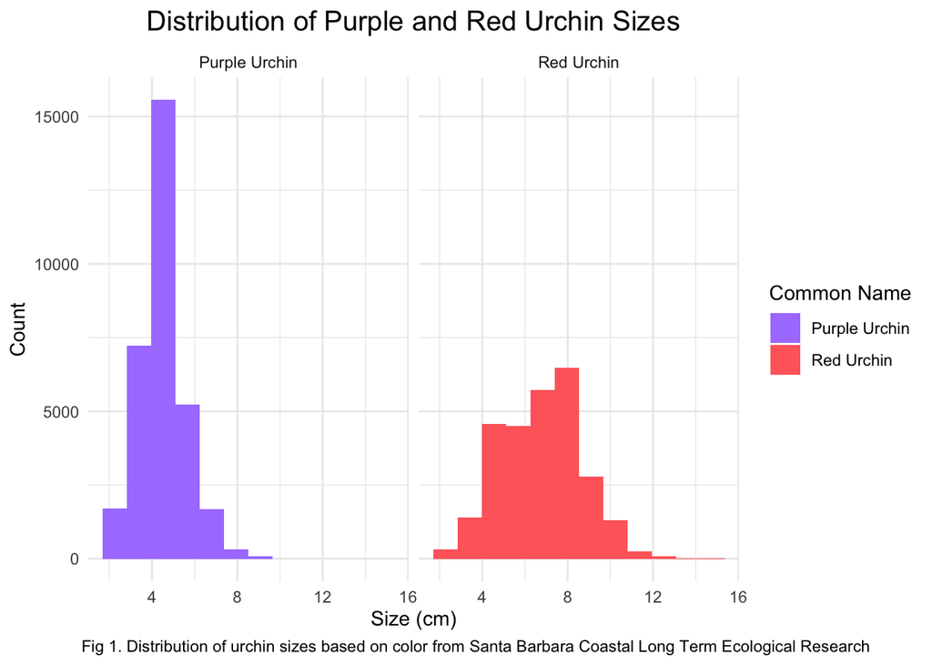

```r
ggplot(data = urchins,
         aes(x = size)) + # histogram only uses x variable~
  geom_histogram(bins = 12, # bins auto sets to 30, so made it smaller to show the trend better
                 aes(fill = common_name)) +
  theme_minimal() +
  scale_fill_manual(values = c("mediumpurple1", "indianred1")) + # scale_fill_manual() allows me to assign specific colors to each facet based on the vector
  facet_wrap(~ common_name) + # facet wrapping by common name to show the differences between the two urchin species
  labs(title = "Distribution of Purple and Red Urchin Sizes",
       key = "Common Name",
       x = "Size (cm)",
       y = "Count",
       caption = "Fig 1. Distribution of urchin sizes based on color from Santa Barbara Coastal Long Term Ecological Research",
       fill = "Common Name") + # "fill" edits the caption name
  theme(plot.title = element_text(hjust = 0.5, size = 15), # hjust allows the title to be centered
        plot.caption = element_text(hjust = 0.05))
```

2. Descriptive Statistics Table: Create a finalized summary table that contains the following statistics for purple and red urchins (still ignoring site as a variable, but including species as a grouping variable): mean, median, standard deviation, and sample size. Use kableExtra (or another package for tables in R) to finalize your table for your knitted document. Add a table caption above your table

```r
urchin_summary <- urchins %>%
  group_by(common_name) %>% # group by common name to separate the two urchin species
  summarize(mean_size = mean(size, na.rm = TRUE), # can also use round() here, but that would make me lose some data in my data frame, which I don't want to. in this case, I'll use define digits in kable() so that values only round for the output table
            median_size = median(size, na.rm = TRUE), # this will create a column that shows the median size of the urchins
            sd_size = sd(size, na.rm = TRUE), #sd() will show the standard deviation of the data
            sample_size = n()) # n() gives the sample size

# Create a table to present the data using kableExtra()
urchin_summary %>%
  kable(digits = 2, # in kable() can use digits = x to round the values in the table - can use a c("x","y") to define the number of digits for each column
        col.names = c("Common Name",
                      "Mean Size (cm)",
                      "Median Size (cm)",
                      "Standard Deviation (cm)",
                      "Sample Size"),
        caption = "<center>Table 1. Summary of Statistics of Purple and Red Urchins<center>") %>%  # <center> will center the text
     kable_styling(bootstrap_options = "striped", full_width = F, position = "center") # bootstrap will make the table look all nice with different colors, I like it
```

Table 1. Summary of Statistics of Purple and Red Urchins

| Common Name | Mean Size (cm) | Median Size (cm) | Standard Deviation (cm) | Sample Size |
| --- | --- | --- | --- | --- |
| Purple Urchin | 4.47 | 4.5 | 1.18 | 31805 |
| Red Urchin | 6.78 | 7.0 | 1.89 | 27408 |

With far over 30 samples, the data does adhere to the central limit theorem; although the purple urchin distribution is slightly right-skewed. As can be seen by the smaller standard deviation and difference in mean and median, the purple urchin data has more concentrated count with less spread. It is observed that red urchin on average are larger than purple by 2.3 cm or a percent difference of 41%.

## Section 2

Explore purple urchin counts by site & year

```r
# Create a subset for purple urchins, create a column to show the site year, and write out the full names of the sites

purple_urchins <- urchins %>%
  filter(common_name == "Purple Urchin") %>% # filter to only include purple urchins
  mutate(mdy = mdy(date)) %>% # create a date class column
  mutate(year = year(mdy)) %>% # create a column with just the year
  mutate(site_full = case_when( # case_when() allows us to say when we see this data value, we want to change it to this
    site == "NAPL" ~ "Naples Reef",
    site == "AQUE" ~ "Arroyo Quemado Reef",
    site == "CARP" ~ "Carpinteria Reef",
    site == "MOHK" ~ "Mohawk Reef",
    site == "IVEE" ~ "Isla Vista Reef"
  ))

# create a table to see the count of purple urchins in each site per year
purple_count <- purple_urchins %>%
  group_by(site_full, year) %>%
  summarize(count = n())
```

Now let’s make a graph to visualize the urchin count at each site over the years

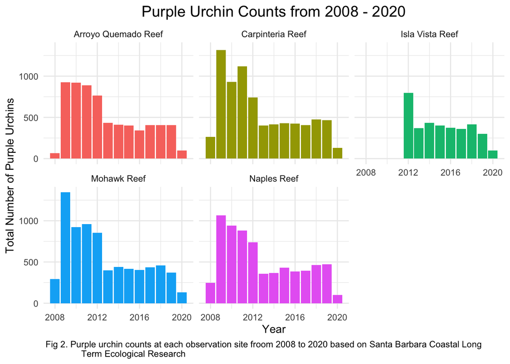

```r
ggplot(data = purple_count,
       aes(x = year, y = count)) +
  geom_col(aes(fill = site_full)) + # chose to use a column graph because it shows the trend in a very visible, discrete way
  facet_wrap(~ site_full) +
  theme_minimal() +
  labs(fill = "Site",
       x = "Year",
       y = "Total Number of Purple Urchins",
       title = "Purple Urchin Counts from 2008 - 2020",
       caption = "Fig 2. Purple urchin counts at each observation site froom 2008 to 2020 based on Santa Barbara Coastal Long \n Term Ecological Research") +
   theme(plot.title = element_text(hjust = 0.5, size = 15),
        plot.caption = element_text(hjust = 0.1),
        legend.position = "none" # removed the legend because the graph already shows the title of the reefs already
        )
```